# Order statistics

### **NOTES ON STATISTICS, PROBABILITY and MATHEMATICS**

### Motivation for $k$ Order Statistics:

The motivation stems from [this question](http://stats.stackexchange.com/q/191258/67822) on CV.

A website receives $1\, \text{order}\,/3 \, \text{min}$. The time until the next order follows an exponential distribution with a $\lambda$ rate parameter of $3 \, \text{min}$. Knowing that there were $10$ clients placing orders online from that site last night we want to calculate the expected waiting time for the first and last orders placed after 5pm (night-time period = time $0$). And we want to find out the time of the $k$-th order.

Every order placed cames at a time. This time is the random variable. Since there are 10 orders, we have $X_1, X_2, X_3,...X_{10}$. To make the derivation more generalized, we can consider $X_n$ as the last entry. They are independent of each other, and they are governed by the *pdf* $\lambda\,e^{-\lambda\,x}$, and *cdf* $1 \,-\, e^-{-\lambda\,x}$, where $x$ stands for time. These will be referred as the *common* density and probability functions, because they are shared by all the variables.

The point now is to describe a different variable: the *order* of the observations. So if we imagine that the callers carry a bib number from $1$ to $10$ that links to the times they place their orders, client $X_1$ may end up being the third one to place the order, when ordering the times of the $10$ clients, in which case the new variable will be denoted as $X_{(3)}$. Notice the small parentheses.

The cdf of this new variable for the last order, $n=10$ will be:

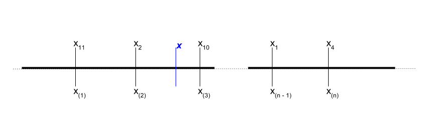

$F_{x_{(n)}}(x) = \Pr(X_{n}\leq x) = \Pr\left(\text{all}\,X_i \leq x\right) = \displaystyle \prod_{k=1}^n \Pr(X_n \leq x) = F(x)^n$, since they are independent and identically ditributed.

In the case of the exponential distribution: $\left (1 - e^{-\lambda\,x \,}\right)^n.$

On the other hand the pdf is:

$\frac{d}{dx}\,F_{x_{(n)}}(x) = n\,(F(x))^{n-1}\, f(x) = n\,\left (1 - e^{-\lambda\,x \,}\right)^{n-1}\,\lambda\,e^{-\lambda x}.$

The pdf and cdf for the first order $(n=1)$ entered on the website are:

$$\begin{align}
F_{x_{(1)}}(x) &= P(\text{min}\, X_i \leq x)\\[2ex]
&= 1 - P(X_{(1)} \geq x)\\[2ex]
&= 1 - (1 - F(x))^n\\[2ex]
&= 1 - (1 - (1 - e^{-\lambda x}))^n\\[2ex]
&= 1 - e^{\,-\lambda x n}.
\end{align}$$

The pdf for the minimum will be:

$$\begin{align}
f_{X_{(1)}}(x)&=\large \frac{d}{dx}\,F_{x_{(1)}}(x)\\[2ex]
&= - n \left(1 - F(x)\right)^{n-1}\,(-f(x))\\[2ex]
&= n \left(1 - F(x)\right)^{n-1}\,(f(x))\\[2ex]
&= n(1 - (1 - e^{-\lambda x}))^{n-1}\, \lambda\,e^{-\lambda
x}\\[2ex]
&= n(e^{-\lambda x (n-1)})\, \lambda\,e^{-\lambda x}\\[2ex]
&= n\, \lambda \, e^{-\lambda x n}.
\end{align}$$

What is the joint pdf for all the order statistics:

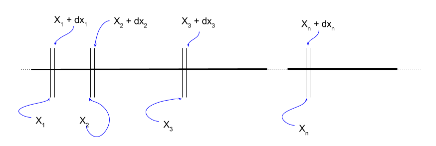

For the actual observations evaluated at the the observation points:

$$\begin{align}
\Pr(X_1 \in [x_1, x_1 + dx_1], X_2 \in [x_2, x_2 + dx_2], \cdots, X_n
\in [x_n, x_n + dx_n]) &= \displaystyle \prod_{k=1}^n \, P(X_k \in
[X_k, x_k + dx_k])\\[2ex]
&= \displaystyle \prod_{k=1}^n \, f(x_k)\,dx_k\\[2ex]
&=f(x_1)\,f(x_2)\,\cdots,f(x_n)\,dx_1\,dx_2,\cdots,\,dx_n.
\end{align}$$

The first part is the joint pdf for $\large f_{x_1,x_2,\cdots,x_n}$ evaluated at $\large x_1, x_2,\cdots, x_n$, or

$\large f_{x_1,x_2,\cdots,x_n\,(x_1, x_2,\cdots, x_n)}\large \,dx_1\,dx_2\,dx_3,\cdots\,dx_n$ given the independence of the marginals.

Now, for the *order statistics* we need to see the indifference to the actual relationship between subject and order:

$$\begin{align}
f_{x_{(1)},x_{(2)},x_{(3)}\cdots,x_{(n)}\,(x_1, x_2,\cdots,
x_n)}\,dx_1\,dx_2\,dx_3,\cdots\,dx_n
&=\Pr\left(X_{(1)} \in [x_1, x_1 + dx_1], X_{(2)} \in [x_2, x_2 +
dx_2], \cdots, X_{(n)} \in [x_n, x_n + dx_n]\right)\\[2ex]
&= n! f(x_1)\,f(x_2)\,\cdots,f(x_n)\large
\,dx_1\,dx_2\,dx_3,\cdots\,dx_n
\end{align}$$

And the pdf is $\large n!\, f(x_1)\,f(x_2)\,\cdots,f(x_n).$

For the marginal pdf of the $\large K$-th order statistic:

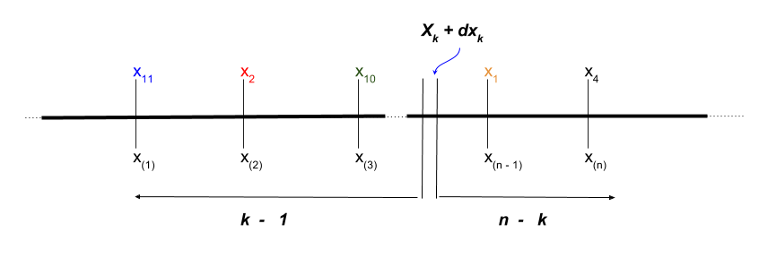

We look at the probability of the observed value to be in the $k$ small interval. There are $n$ choices for the one value in the small interval ($X_{(k)}$) with probability $f(x)\,dx$. There are $k - 1$ to the left; and $n - k$ to the right. So we choose the ones to the left with the combination below, and we look at the probability of being to the left of $x$: $\large F(x)^{k-1}\,(1-F(x))^{n-k})$ in a binomial:

$$f_{x{(k)}}(x)\,dx
= n\,\binom{n-1}{k-1} (f(x)\,dx)
\,F(x)^{k-1}\,\left(1-F(x)\right)^{n-k}$$

Simplifying,

$$f_{x{(k)}}(x) = n\,\binom{n-1}{ k-1} \,
\,F(x)^{k-1}\,\left(1-F(x)\right)^{n-k}\, f(x)$$

In the case of the exponential distribution:

Integrating:

[figure not shown]

And $_2F_1$(a,b; c; x) is the hypergeometric function.

[Home Page](http://rinterested.github.io/statistics/index.html)

**NOTE: These are tentative notes on different topics for personal use - expect mistakes and misunderstandings.**